# Final Project

Nithin Varghese

2026-08-12

```r
# Load your packages here
library(tidyverse)
library(dplyr)
library(patchwork)
library(readr)
library(ggmosaic)
library(sf)
library(rnaturalearth)
library(rnaturalearthdata)
# Add any additional packages using library() only, not install.packages()
```

# Section 1 Data Description, Aquisition, and Wrangling

*The data was downloaded from QLD government open data porta* *url- https://www.data.qld.gov.au/dataset/crash-data-from-queensland-roads/resource/e88943c0-5968-4972-a15f-38e120d72ec0?inner_span=True*

```r
# Load the data
crash_data <- read_csv("data\\crash_locations.csv")
# Example: my_data <- read_csv("data/my_dataset.csv")
```

```r
# Get an overview of the dataset
glimpse(crash_data)
```

```
## Rows: 408,271
## Columns: 52
## $ Crash_Ref_Number                <dbl> 1, 2, 3, 4, 5, 6, 7, 8, 9, 10, 11, 12,…
## $ Crash_Severity                  <chr> "Medical treatment", "Property damage …
## $ Crash_Year                      <dbl> 2006, 2007, 2008, 2007, 2007, 2008, 20…
## $ Crash_Month                     <chr> "November", "August", "May", "August",…
## $ Crash_Day_Of_Week               <chr> "Saturday", "Wednesday", "Saturday", "…
## $ Crash_Hour                      <dbl> 17, 9, 17, 2, 1, 6, 9, 9, 15, 13, 4, 4…
## $ Crash_Nature                    <chr> "Hit parked vehicle", "Rear-end", "Hit…
## $ Crash_Type                      <chr> "Single Vehicle", "Multi-Vehicle", "Si…
## $ Crash_Longitude                 <dbl> 153.5497, 153.0551, 153.4071, 146.7124…
## $ Crash_Latitude                  <dbl> -28.16524, -27.52444, -28.04818, -19.2…
## $ Crash_Street                    <chr> "Boundary St", "South East Arterial Rd…
## $ Crash_Street_Intersecting       <chr> NA, NA, "Southport - Burleigh Rd", NA,…
## $ State_Road_Name                 <chr> NA, "South-East Arterial Road (Pacific…
```

[output cut: 39 more lines]

```r
range(crash_data$Crash_Year)
```

```
## [1] 2001 2024
```

*There 52 columns in the dataset and 408,271 rows. Some columns that are certainly not going to be used are to be removed*.

*There are several columns dedicated to information pertaining to geographical location. As far as the scope of this study is concerned we are only interested in local government area, statistical area 3, other columns related to location were omitted. Statistical area 3 was chosen as this is classification used for town planning,traffic analysis and infrastructure development*.

```r
# use select function to retain only the required columns

crash_filtered <- crash_data |>
  select( "Crash_Ref_Number","Crash_Severity", "Crash_Year", "Crash_Month", "Crash_Day_Of_Week", "Crash_Hour", "Loc_Local_Government_Area","Loc_ABS_Statistical_Area_3", "Crash_Roadway_Feature",)

glimpse(crash_filtered)
```

```
## Rows: 408,271
## Columns: 9
## $ Crash_Ref_Number           <dbl> 1, 2, 3, 4, 5, 6, 7, 8, 9, 10, 11, 12, 13, …
## $ Crash_Severity             <chr> "Medical treatment", "Property damage only"…
## $ Crash_Year                 <dbl> 2006, 2007, 2008, 2007, 2007, 2008, 2007, 2…
## $ Crash_Month                <chr> "November", "August", "May", "August", "Jun…
## $ Crash_Day_Of_Week          <chr> "Saturday", "Wednesday", "Saturday", "Sunda…
## $ Crash_Hour                 <dbl> 17, 9, 17, 2, 1, 6, 9, 9, 15, 13, 4, 4, 18,…
## $ Loc_Local_Government_Area  <chr> "Gold Coast City", "Brisbane City", "Gold C…
## $ Loc_ABS_Statistical_Area_3 <chr> "Coolangatta", "Nathan", "Broadbeach - Burl…
## $ Crash_Roadway_Feature      <chr> "No Roadway Feature", "No Roadway Feature",…
```

```r
# check for NA values

colSums(is.na(crash_filtered))
```

```
##           Crash_Ref_Number             Crash_Severity
##                          0                          0
##                 Crash_Year                Crash_Month
##                          0                          0
##          Crash_Day_Of_Week                 Crash_Hour
##                          0                          0
##  Loc_Local_Government_Area Loc_ABS_Statistical_Area_3
##                          0                          0
##      Crash_Roadway_Feature
##                          0
```

- There are no ‘NA’ values seen.

# Section 2 Exploratory Findings That Shaped Your Story and Data cleaning

*Exploratory analysis was done to identify the trend over time in the incidence of accidents across whole of QLD* .

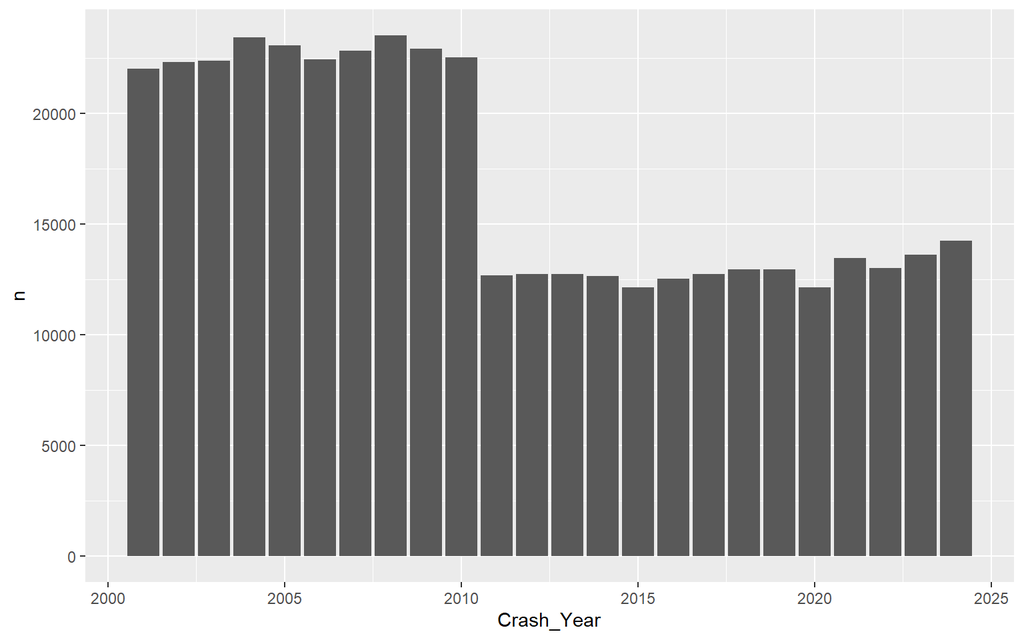

```r
# Exploratory data analysis

crash_filtered|>
  count(Crash_Year) |>
  ggplot(aes(x = Crash_Year, y = n)) +
  geom_col()
```

*It appears there was a sudden drop in number of crashes post 2010. This prompted further investigation.Comparison was made to check if there are any changes in how crashes are recorded*.

```r
# Exploratory data analysis

crash_filtered |>
  filter(Crash_Year <= "2010")|>
  distinct(Crash_Severity)
```

```
## # A tibble: 5 × 1
##   Crash_Severity
##   <chr>
## 1 Medical treatment
## 2 Property damage only
## 3 Hospitalisation
## 4 Minor injury
## 5 Fatal
```

```r
crash_filtered |>
  filter(Crash_Year >= "2011")|>
  distinct(Crash_Severity)
```

```
## # A tibble: 4 × 1
##   Crash_Severity
##   <chr>
## 1 Medical treatment
## 2 Hospitalisation
## 3 Minor injury
## 4 Fatal
```

*Looking at the count of unique values it is identified that crashes resulting in ‘property damage only’ was not being recorded post 2010. This is further confirmed in the description provided in the data source.It was also observed the total number of crashes remained mostly steady until 2020, then there is a gradual upward trend. Therefore, further exploration focused only on data from 2020 on wards*.

```r
# Data cleaning and wrangling

crash_filtered <- crash_filtered |>
  filter(Crash_Year >= 2020)
range(crash_filtered$Crash_Year)
```

```
## [1] 2020 2024
```

*For the purposes of this analysis we will use only two categories of severity, “Major” and “Minor”. Crashes that were fatal or required hospitalization will be clubbed together to form “Major” category and others will be “Minor”*

```r
# Data cleaning and wrangling

unique(crash_filtered$Crash_Severity)
```

```
## [1] "Medical treatment" "Minor injury"      "Hospitalisation"
## [4] "Fatal"
```

```r
crash_filtered <- crash_filtered |>
  mutate(Crash_Severity = case_when(
    Crash_Severity == "Fatal" ~ "Major",
    Crash_Severity == "Hospitalisation" ~ "Major",
    Crash_Severity == "Medical treatment" ~ "Minor",
    Crash_Severity == "Minor injury" ~ "Minor"
  ))

unique(crash_filtered$Crash_Severity)
```

```
## [1] "Minor" "Major"
```

*The next obvious question was where does most accidents happen. The data was aggregated at LGA levels based on crash location*.

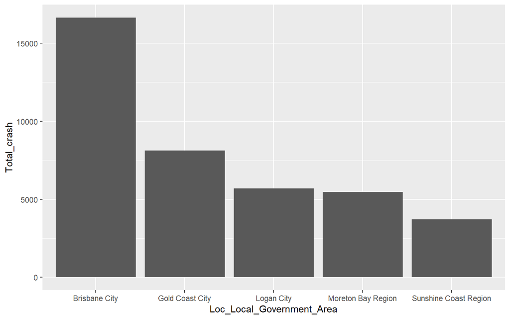

```r
# Exploratory data analysis

crash_filtered |>
  select(Loc_Local_Government_Area)|>
  group_by(Loc_Local_Government_Area)|>
  summarise(Total_crash = n())|>
  arrange(desc(Total_crash))|>
  slice_head(n =5)|>
  ggplot(aes(x = Loc_Local_Government_Area, y = Total_crash))+
  geom_col()
```

*It is very obvious that Brisbane city council is the biggest contributor to road accidents*. *Further exploration was done into crash data of Brisbane alone to identify seasonal/hourly trends*.

```r
# filter the data frame to include only Brisbane local government data

crash_brisbane <- crash_filtered |>
  filter(Loc_Local_Government_Area =="Brisbane City")
```

*Further exploration into geographical distribution of crashes within the Brisbane LGA, data aggregated at statistical area 3(sa3) division. sa3 column was used to aggregate data as it a standard ABS classification used for statistical analysis, regional planning and infrastructure development*.

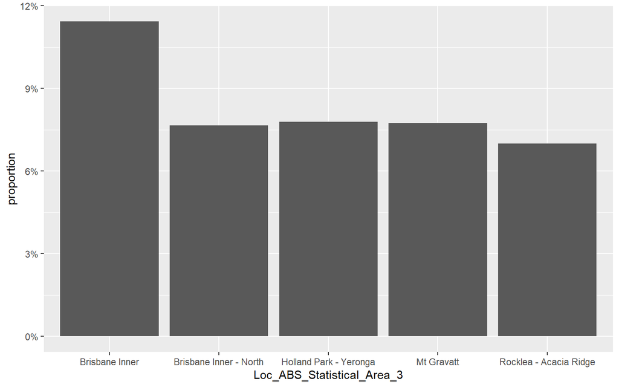

```r
# Exploratory data analysis

crash_brisbane |>
  count(Loc_ABS_Statistical_Area_3) |>
  mutate(proportion = n / sum(n)) |>
  arrange(desc(proportion)) |>
  slice_max(order_by = proportion, n = 5) |>
  ggplot(aes(x = Loc_ABS_Statistical_Area_3, y = proportion)) +
  geom_col()+
  scale_y_continuous(labels = scales::percent)
```

Out of all sa3 divisions in Brisbane LGA, sa3 Brisbane inner alone accounts for nearly 12 percent of total accidents, despite being smallest geographically.Further exploration therefore zoomed into patterns within sa3 - Brisbane inner.

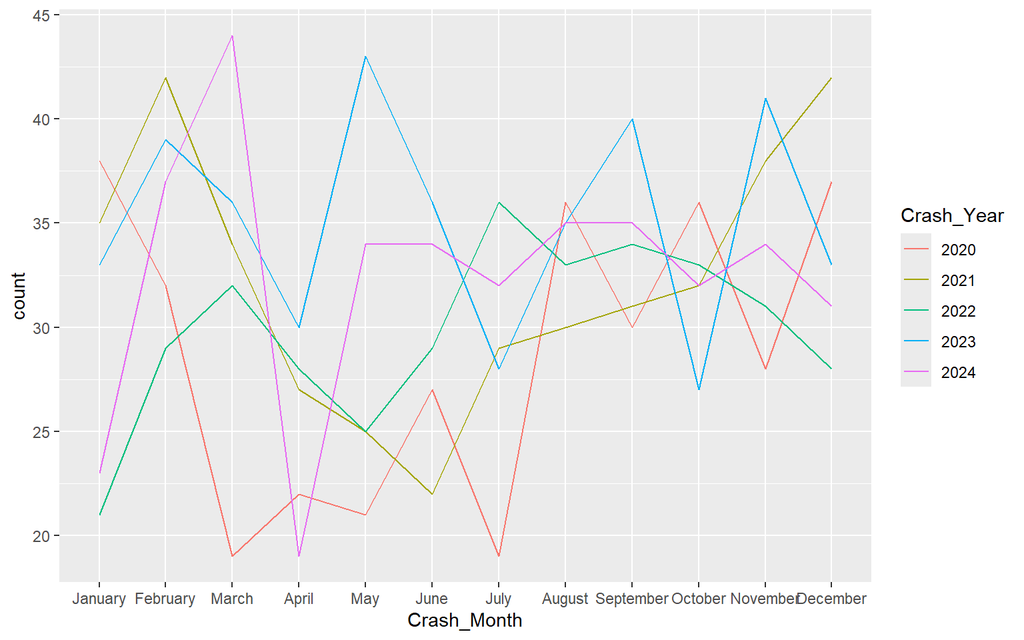

```r
# Exploratory data analysis

crash_seasonal<-crash_brisbane |>
  mutate(
    Crash_Month = factor(
      Crash_Month,levels = c (
        "January", "February", "March", "April","May", "June", "July", "August","September", "October", "November", "December")
      )
    )|>
  filter(Loc_ABS_Statistical_Area_3 == "Brisbane Inner")|>
  group_by(Crash_Year,Crash_Month)|>
  summarise(count = n(),.groups = "drop")

crash_seasonal |>
  mutate(Crash_Year = as.factor(Crash_Year))|>
  ggplot(aes(x = Crash_Month, y = count, group = Crash_Year, colour = Crash_Year))+
  geom_line()
```

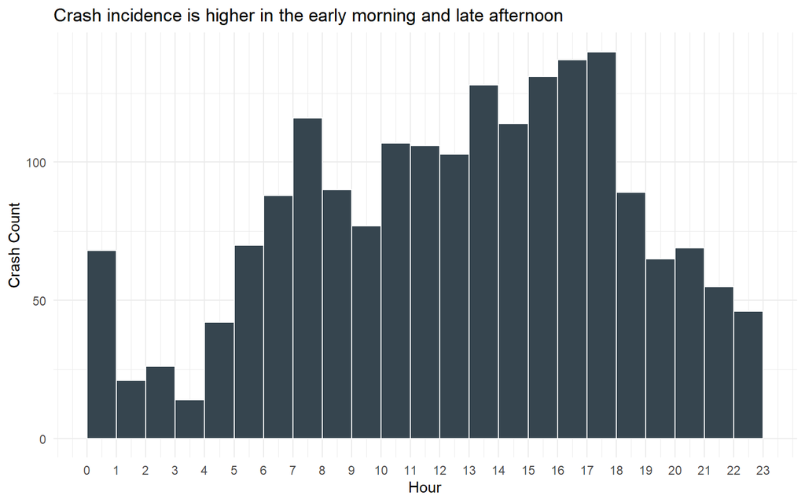

```r
# Exploratory data analysis

crash_hour <- crash_brisbane |>
  filter(Loc_ABS_Statistical_Area_3 == "Brisbane Inner")|>
  ggplot(aes(x= Crash_Hour))+
  geom_histogram(binwidth = 1,boundary = 0, fill = "#36454f", colour = "white")+
  scale_x_continuous(breaks = 0:23) +
  labs(
    title = "Crash incidence is higher in the early morning and late afternoon",
    x = "Hour",
    y = "Crash Count"
  ) +
  theme_minimal()

crash_hour
```

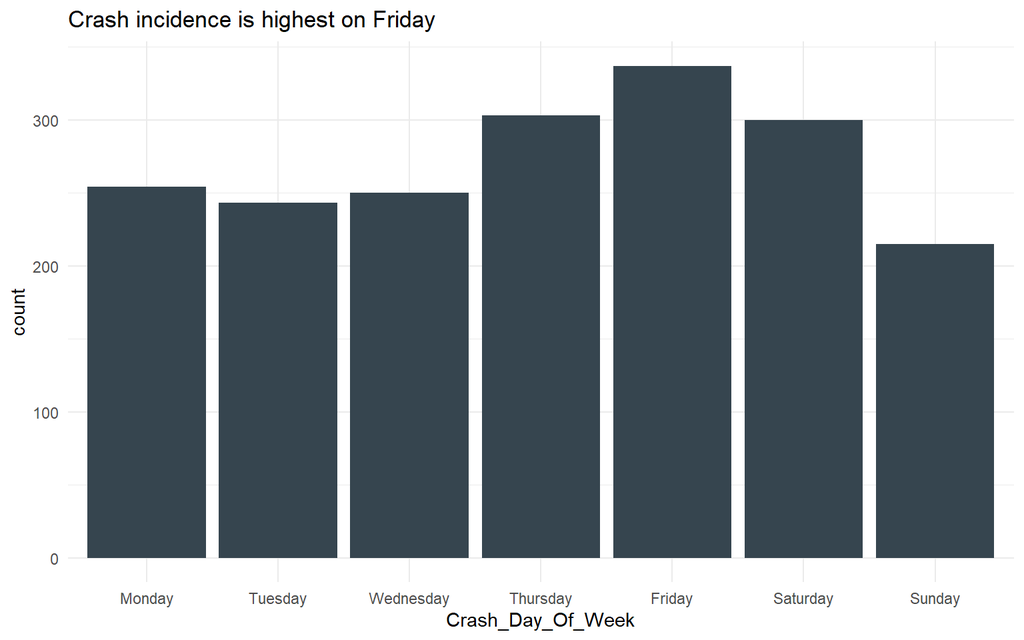

```r
# Exploratory data analysis

crash_day <- crash_brisbane |>
  filter(Loc_ABS_Statistical_Area_3 == "Brisbane Inner")|>
  mutate(Crash_Day_Of_Week = factor(Crash_Day_Of_Week, levels = c("Monday","Tuesday","Wednesday","Thursday","Friday","Saturday","Sunday")))|>

  ggplot(aes(x= Crash_Day_Of_Week))+
  geom_bar(fill = "#36454F")+
  labs(
    title = "Crash incidence is highest on Friday"
  )+
  theme_minimal()

crash_day
```

```r
# Exploratory data analysis

crash_brisbane |>
  filter(Loc_ABS_Statistical_Area_3=="Brisbane Inner")|>
  group_by(Crash_Roadway_Feature) |>
  summarise(Count= n())|>
  arrange(desc(Count))
```

```
## # A tibble: 10 × 2
##    Crash_Roadway_Feature      Count
##    <chr>                      <int>
##  1 No Roadway Feature           826
##  2 Intersection - Cross         435
##  3 Intersection - T-Junction    426
##  4 Intersection - Interchange    86
##  5 Bridge/Causeway               75
##  6 Merge Lane                    15
##  7 Bikeway                       13
##  8 Intersection - Roundabout     13
##  9 Intersection - 5+ way         11
## 10 Intersection - Y-Junction      2
```

*Most accidents seem to happen mid block rather than intersection. However intersections are scattered across different categories.Intersection was consolidated into single category get a broader picture*.

```r
crash_feature<-crash_brisbane|>
  filter(Loc_ABS_Statistical_Area_3=="Brisbane Inner")|>
  mutate(
    Crash_Roadway_Feature = case_when(
     Crash_Roadway_Feature %in% c(
        "Intersection - Cross","Intersection - T-Junction","Intersection - Interchange","Intersection - 5+ way","Intersection - Roundabout","Intersection - Y-Junction"
      ) ~ "Intersection" , TRUE~Crash_Roadway_Feature
    )
  )

crash_feature |>
  group_by(Crash_Roadway_Feature) |>
  summarise(Count= n())|>
  arrange(desc(Count))
```

```
## # A tibble: 5 × 2
##   Crash_Roadway_Feature Count
##   <chr>                 <int>
## 1 Intersection            973
## 2 No Roadway Feature      826
## 3 Bridge/Causeway          75
## 4 Merge Lane               15
## 5 Bikeway                  13
```

Looking at broader picture, most crashes are happening at intersections.

```r
# Any exploratory plots or summaries you want to include here
```

# Section 3 Storyboard

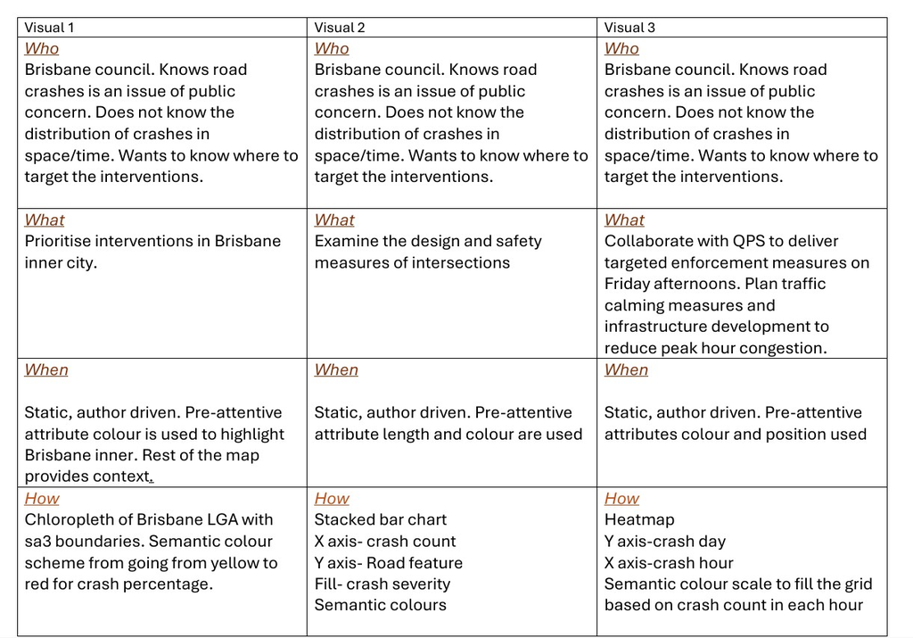

```r
knitr::include_graphics("images/storyboard.jpg")
```

# Section 4 Visualisations

## Visualisation 1

```r
# aggregate the crash count at sa 3 level

crash_map <- crash_brisbane |>
  count(Loc_ABS_Statistical_Area_3)|>
  mutate(Proportion = (n/sum(n)))

# shapefile of sa3 boundaries in Brisbane dowloaded from https://www.abs.gov.au/statistics/standards/australian-statistical-geography-standard-asgs/edition-3-july-2021-june-2026/access-and-downloads/digital-boundary-files#downloads-for-gda94-digital-boundary-files

# create base map of Brisbane with statistical area 3 boundaries

sa3 <- st_read("data\\SA3\\SA3_2021_AUST_GDA94.shp")    #read the shape file
sa3_filtered<-sa3|>          #    filter to just QLD data and drop unnecessary columns
  filter(STE_NAME21=="Queensland")|>
  select(SA3_NAME21)

# shape file with sa3 boundaries do not have LGA boundaries, separate shape file for LGA boundaries for whole of QLD obtained from
# https://www.abs.gov.au/statistics/standards/australian-statistical-geography-standard-asgs/edition-3-july-2021-june-2026/access-and-downloads/digital-boundary-files#downloads-for-gda94-digital-boundary-files

lga<-st_read("data\\LGA\\LGA_2025_AUST_GDA94.shp") # read shape file with LGA boundaries
lga_brisbane<-lga|>         #     filter to just Brisbane data and drop unnecessary columns
  filter(LGA_NAME25=="Brisbane")|>
  select(LGA_NAME25)

brisbane_lga <-st_intersection(sa3_filtered,lga_brisbane) # clip the sa3 shape file to show only the Brisbane LGA area, intersection keeps only the overlapping area

crash_joined <- left_join(brisbane_lga,crash_map,by = c("SA3_NAME21" = "Loc_ABS_Statistical_Area_3")) # create new sf object combining spatial and non-spatial data
```

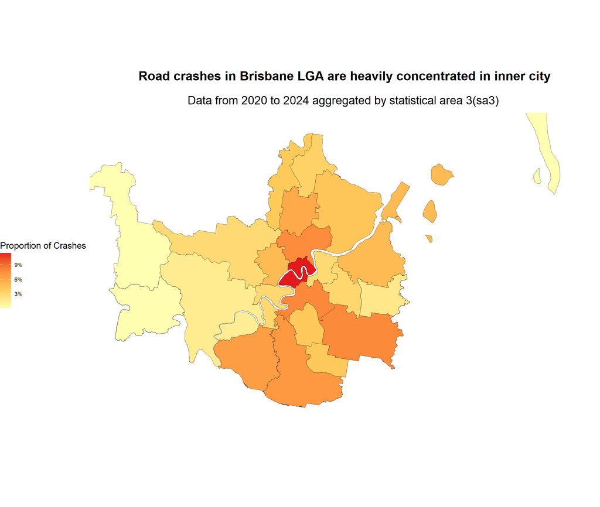

```r
ggplot(crash_joined) +
  geom_sf(aes(fill = Proportion)) +
  scale_fill_gradientn(name = "Proportion of Crashes",
  colours = c("#FFFFB2", "#FECC5C", "#FD8D3C", "#E31A1C"),
  na.value = "transparent",
  labels=scales::percent
) +
  labs(title = "Road crashes in Brisbane LGA are heavily concentrated in inner city",
       subtitle = "Data from 2020 to 2024 aggregated by statistical area 3(sa3) ",
       x = NULL, y = NULL) +

  coord_sf(
  xlim = c(152.7, 153.5),
  ylim = c(-27.7, -27.25),
  expand = FALSE)+
  theme_void()+
  theme(
    legend.position = "left",
    legend.title = element_text(size = 14),
    plot.title = element_text(hjust=0.5,margin = margin(b = 20),size = 20,face = "bold"),
    plot.subtitle = element_text(hjust=0.5,margin = margin(b = 10),size = 18)
    )
```

## Visualisation 2

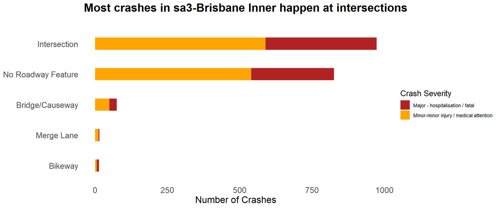

```r
 crash_feature|>

  ggplot(
       aes(x = fct_rev(fct_infreq(Crash_Roadway_Feature)),
           fill = Crash_Severity)) +
  geom_bar(width = 0.4) +
  coord_flip() +
  theme_minimal() +
  labs(
    title = "Most crashes in sa3-Brisbane Inner happen at intersections",
    x = NULL,
    y = "Number of Crashes"
  )+

  scale_fill_manual(name = "Crash Severity",values=c("firebrick","orange"),
                    labels = c("Major - hospitalisation / fatal","Minor-minor injury / medical attention"))+
  theme(panel.grid = element_blank())+
  theme(
    legend.title = element_text(size = 14),
    plot.title = element_text(hjust=-0.2,margin = margin(b = 20),size = 20,face = "bold"),
    axis.text.x = element_text(size = 14),
    axis.text.y = element_text(size = 14),
    axis.title.x = element_text(size = 16)
    )
```

## Visualisation 3

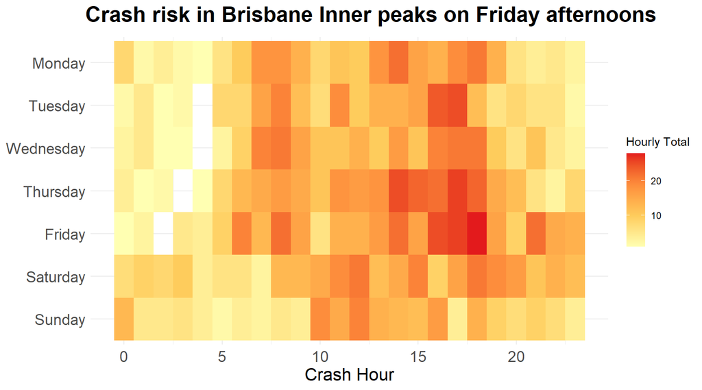

```r
crash_brisbane|>
  filter(Loc_ABS_Statistical_Area_3 == "Brisbane Inner")|>
  mutate(Crash_Day_Of_Week = factor(Crash_Day_Of_Week,levels = c("Monday","Tuesday","Wednesday","Thursday","Friday","Saturday","Sunday")))|>
  group_by(Crash_Day_Of_Week,Crash_Hour)|>
  mutate(Hourly_Total = n())|>
  ggplot(aes(x= Crash_Hour,y= fct_rev(Crash_Day_Of_Week), fill = Hourly_Total))+
  geom_tile()+
  scale_fill_gradientn(name ="Hourly Total",
  colours = c("#FFFFB2", "#FECC5C", "#FD8D3C", "#E31A1C"))+
  labs(title = "Crash risk in Brisbane Inner peaks on Friday afternoons",
       x  = "Crash Hour", y = NULL)+
  theme_minimal()+
  theme(
    plot.title = element_text(hjust=0.1,size = 20,face = "bold",margin = margin(b=10)),
    axis.text.x = element_text(size = 14),
    axis.text.y = element_text(size = 14),
    axis.title.x = element_text(size = 16)
    )
```

# Section 5 Written Justification

*A choropleth map was selected to visualise the relative concentration of crashes across SA3 regions in Brisbane. As the primary audience is Brisbane City Council, it is reasonable to assume a strong existing familiarity with Brisbane’s geography and statistical divisions, enabling viewers to interpret the spatial patterns quickly and accurately. The choropleth format allows immediate comparison between Brisbane Inner and surrounding SA3 regions, making regional differences apparent immediately*.

*Colour intensity serves as a highly effective pre-attentive visual attribute, enabling users to rapidly identify areas with higher crash concentrations without extensive cognitive effort. The visualisation focuses on a single key measure across geographic regions, limiting the number of variables displayed and therefore reducing cognitive load. This directs attention to the central insight that crashes are disproportionately concentrated in Brisbane Inner. Using semantic colour scheme was a key design decision, aligning with general perception of severity*.

*Furthermore, the choropleth effectively communicates that, despite its relatively small geographic area, Brisbane Inner accounts for the highest proportion of crashes among all SA3 divisions. By combining geographic context with quantitative comparison, the map provides a clear and intuitive representation of the spatial distribution of crash concentration*.

*Another key design decisions were to avoid labelling the sa3 divisions as Brisbane Council officials are expected to be able to recognise them looking at the map. Especially with Brisbane River running through middle of the city, it is easily recognisable and avoiding labels reduce clutter*.

*A stacked bar chart was chosen to visualise the distribution of crashes across different roadway feature categories. Given that the intended audience is Brisbane City Council, it is reasonable to assume familiarity with interpreting bar charts. The pre-attentive attribute of length enables rapid comparison between categories, clearly highlighting that intersections account for the highest number of crashes. Stacking the bars further allows viewers to assess both the total number of crashes and the relative contribution of major and minor crashes within each roadway feature category. A semantic colour scheme was applied, with red representing major crashes and orange representing minor crashes. This is consistent with common perception of severity*.

*A heatmap was selected to visualise the hourly distribution of crashes because it effectively highlights temporal patterns and variations in crash frequency across different times of the day. The pre-attentive attribute of colour intensity allows viewers to quickly distinguish between low- and high-crash periods without the need to compare individual values. Identifying temporal patterns and variations is the priority here and precision is not required. This makes heatmap an ideal choice. Also, the heatmap is a compact way of displaying the inter-connection between three variables, which cannot be achieved using other chart types*.